# hw2

bora yıldırım

2022-05-27

#Bora Yıldırım

#IE360 HW 2

setwd(“/Users/bora.yildirim/Desktop”) install.packages(“fpp2”) install.packages(“rmarkdown”)

```r
library(ggplot2)
library(forecast)
library(readxl)
library(zoo)
library(fpp2)
library(rmarkdown)
```

```r
#I converted the csv data to the excel file to have numeric values
```

```r
data_gasoline <- read.csv("IE360_Spring22_HW2_data.csv")
str(data_gasoline)
```

```
## 'data.frame':    32 obs. of  11 variables:
##  $ Quarter        : chr  "2000_Q1" "2000_Q2" "2000_Q3" "2000_Q4" ...
##  $ UGS            : int  1128971 1199569 1370167 1127548 1033918 1019754 1209916 1002789 893722 1027252 ...
##  $ RNUV           : num  0.0146 0.0205 0.0207 0.0163 0.0071 0.0051 0.0041 0.0048 0.0012 0.0032 ...
##  $ NLPG           : int  940000 941000 943500 948000 950000 955000 967500 990000 1000000 1001000 ...
##  $ PU             : num  469 459 440 402 412 ...
##  $ PG             : num  356 345 327 301 306 ...
##  $ NUGV           : int  4647500 4742876 4840931 4919685 4954754 4980204 5000446 5024693 5030810 5046960 ...
##  $ NDGV           : num  282 284 287 288 288 ...
##  $ GNP.Agriculture: int  1040173 1760460 6974808 3267125 1004528 1449357 5890424 1940854 832953 1419764 ...
##  $ GNP.Commerce   : int  3483132 4525451 5915204 4929778 3418387 4359831 5925547 4559190 3374849 4363782 ...
##  $ GNP.Total      : int  18022686 21797130 30050207 24480153 15832648 20296918 28017963 22656812 18393446 20382635 ...
```

as.numeric(data_gasoline$UGS) as.numeric(data_gasoline$RNUV) as.numeric(data_gasoline$NLPG) as.numeric(data_gasoline$PU) as.numeric(data_gasoline$PG) as.numeric(data_gasoline$NUGV) as.numeric(data_gasoline$GNP.Agriculture) as.numeric(data_gasoline$GNP.Commerce) as.numeric(data_gasoline$GNP.Total)

#Converting quarters into date objects new_quarter <- seq(as.Date(“2000-01-01”), by=“quarter”, length.out =32) data_gasoline$Quarter <- new_quarter

#Plotting of UGS time series

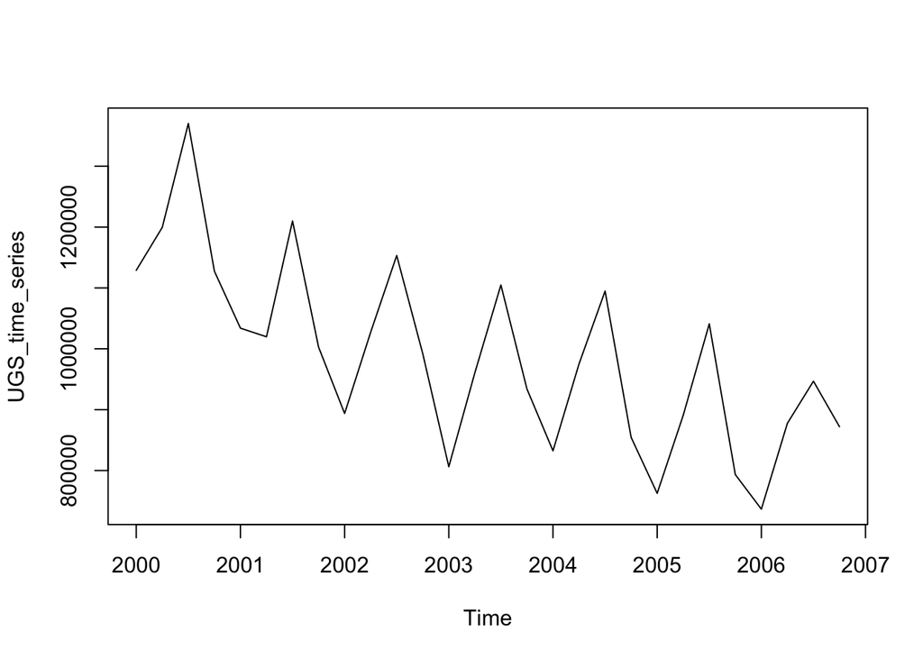

```r
UGS_time_series<-  ts(data_gasoline$UGS[1:28],start = c(2000,1), frequency = 4 )
plot(UGS_time_series)
```

#Data seems to has a decreasing trend line, and it is not stationary

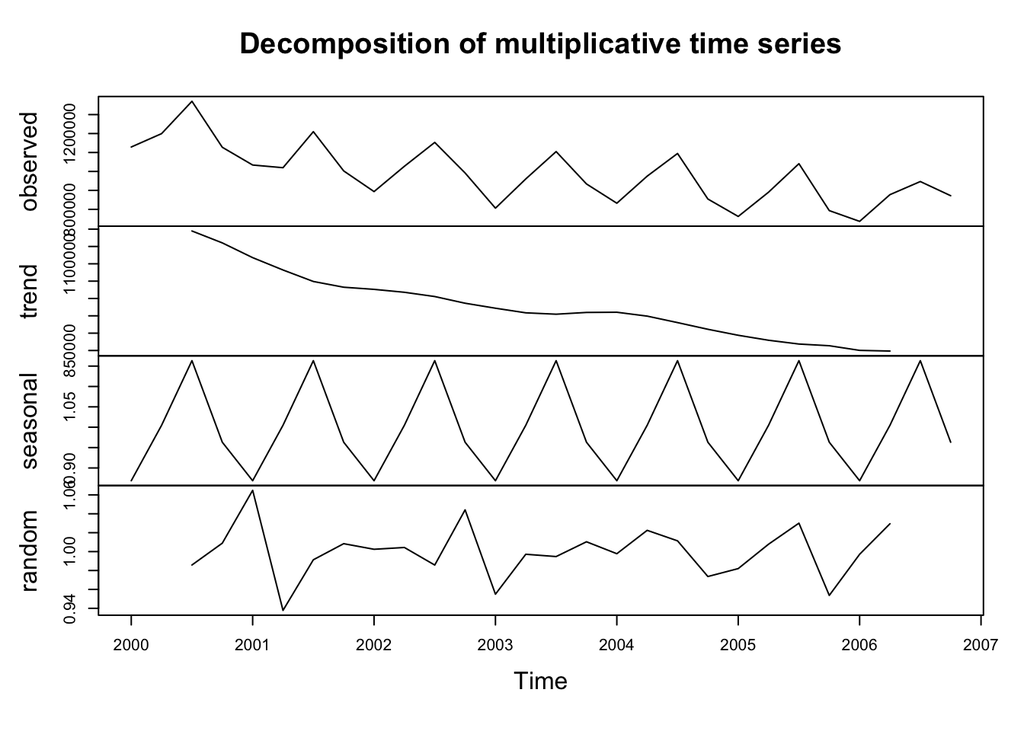

```r
 UGS_decomposed <- decompose(UGS_time_series, type="multiplicative")
plot(UGS_decomposed)
```

#I will take the difference between observations to obtain a stationary time series

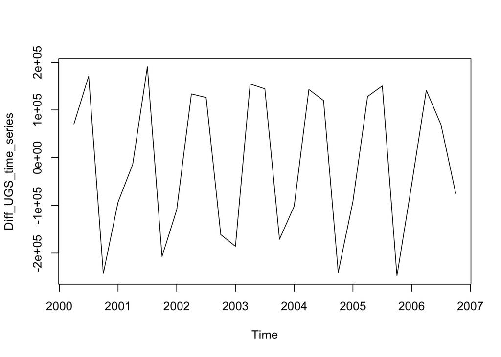

```r
Diff_UGS_time_series <- diff(UGS_time_series)
plot(Diff_UGS_time_series)
```

#autocorrelation plot shows us at lag 1 and lag 4 acf is out of the boundary which shows us the seasonality effect.

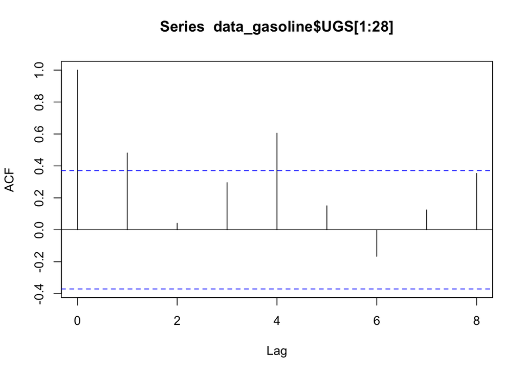

```r
acf(data_gasoline$UGS[1:28], 8)
```

## forecasting

#seasonal naive method, p-value = 9.137e-09, residual SD=223671.49,residuals seem random, all acf is between %95 conf. interval boundaries

snaive_model_1 <- snaive(Diff_UGS_time_series) summary(snaive_model_1) checkresiduals(snaive_model_1)

#exponential smooting, p-value = 9.203e-11, residual SD(sigma)= 0.1281, residuals seem to have a pattern, some acf crosses %95 conf interval boundaries

es_model_2 <- ets(UGS_time_series) summary(es_model_2) checkresiduals(es_model_2)

#ARIMA method, d for eliminating the trend, and D for eliminating seasonality, p-value= 2.971e-11, residual SD= 149799.9 , some acf are out of boundaries, residuals seem to have a strong pattern

arima_model_3 <- auto.arima(UGS_time_series[1:28], d= 1, D= 1) summary(arima_model_3) checkresiduals(arima_model_3)

lm_model_4 <- lm(UGS[1:28] ~ RNUV[1:28] + NLPG[1:28] + PU[1:28] + PG[1:28] + NUGV[1:28] + NDGV[1:28] + GNP.Agriculture[1:28] + GNP.Commerce[1:28] + GNP.Total[1:28],data_gasoline) summary(lm_model_4) checkresiduals(lm_model_4)

##Residual standard error: 40090 on 18 degrees of freedom ##Multiple R-squared: 0.953, Adjusted R-squared: 0.9295 ##F-statistic: 40.58 on 9 and 18 DF, p-value: 3.879e-10

```r
#define seasonality
data_gasoline$trend=seq(0,31,by=1)

#define trend
data_gasoline$quarter=seq(1,4,by=1)
```

#model with seasonality lm_model_5 <- lm(UGS[1:28] ~ RNUV[1:28] + NLPG[1:28] + PU[1:28] + PG[1:28] + NUGV[1:28] + NDGV[1:28] + GNP.Agriculture[1:28] + GNP.Commerce[1:28] + GNP.Total[1:28] + quarter[1:28],data_gasoline) summary(lm_model_5) checkresiduals(lm_model_5)

##Residual standard error: 38770 on 17 degrees of freedom ##Multiple R-squared: 0.9585, Adjusted R-squared: 0.9341 ##F-statistic: 39.27 on 10 and 17 DF, p-value: 9.187e-10

#model with trend and seasonality lm_model_6 <- lm(UGS[1:28] ~ RNUV[1:28] + NLPG[1:28] + PU[1:28] + PG[1:28] + NUGV[1:28] + NDGV[1:28] + GNP.Agriculture[1:28] + GNP.Commerce[1:28] + GNP.Total[1:28] + quarter[1:28] + trend[1:28],data_gasoline) summary(lm_model_6) checkresiduals(lm_model_6)

##Residual standard error: 37340 on 16 degrees of freedom ##Multiple R-squared: 0.9638, Adjusted R-squared: 0.9389 ##F-statistic: 38.71 on 11 and 16 DF, p-value: 2.07e-09

```r
#define lag
data_gasoline$lag <- NA
data_gasoline$lag <- dplyr::lag(data_gasoline$UGS)
```

#model with trend seasonality and lag variables lm_model_7 <- lm(UGS[1:28] ~ RNUV[1:28] + NLPG[1:28] + PU[1:28] + PG[1:28] + NUGV[1:28] + NDGV[1:28] + GNP.Agriculture[1:28] + GNP.Commerce[1:28] + GNP.Total[1:28] + quarter[1:28] + trend[1:28] + lag[1:28],data_gasoline) summary(lm_model_7) checkresiduals(lm_model_7)

```r
lm_model_7 <- lm(UGS ~ RNUV + NLPG + PU + PG + NUGV + NDGV +
GNP.Agriculture + GNP.Commerce + GNP.Total + quarter + trend +
lag,data_gasoline)
```

```r
summary(lm_model_7)
```

```
##
## Call:
## lm(formula = UGS ~ RNUV + NLPG + PU + PG + NUGV + NDGV + GNP.Agriculture +
##     GNP.Commerce + GNP.Total + quarter + trend + lag, data = data_gasoline)
##
## Residuals:
##    Min     1Q Median     3Q    Max
## -45173 -12167  -2418  12960  36533
##
## Coefficients:
##                   Estimate Std. Error t value Pr(>|t|)
## (Intercept)      2.979e+06  1.161e+06   2.566   0.0224 *
## RNUV             1.187e+06  1.856e+06   0.640   0.5328
## NLPG            -1.773e-01  1.940e-01  -0.914   0.3762
## PU              -4.180e+02  1.081e+03  -0.387   0.7049
## PG              -2.842e+02  1.537e+03  -0.185   0.8559
## NUGV            -7.987e-01  4.760e-01  -1.678   0.1156
## NDGV             9.941e+03  4.985e+03   1.994   0.0660 .
## GNP.Agriculture  3.193e-02  2.007e-02   1.591   0.1340
## GNP.Commerce     6.389e-02  4.903e-02   1.303   0.2136
## GNP.Total       -1.086e-02  1.440e-02  -0.754   0.4632
## quarter          4.587e+04  2.637e+04   1.739   0.1039
## trend           -1.963e+03  1.616e+04  -0.121   0.9051
## lag             -5.045e-01  1.408e-01  -3.582   0.0030 **
## ---
## Signif. codes:  0 '***' 0.001 '**' 0.01 '*' 0.05 '.' 0.1 ' ' 1
##
## Residual standard error: 28560 on 14 degrees of freedom
##   (5 observations deleted due to missingness)
## Multiple R-squared:  0.9808, Adjusted R-squared:  0.9644
## F-statistic: 59.61 on 12 and 14 DF,  p-value: 6.987e-10
```

checkresiduals(lm_model_7)

```r
data_gasoline <- as.data.frame(data_gasoline)
a29 <- predict(lm_model_7,newdata = data_gasoline[29,3:14])
a30 <- predict(lm_model_7,newdata = data_gasoline[30,3:14])
a31 <- predict(lm_model_7,newdata = data_gasoline[31,3:14])
a32 <- predict(lm_model_7,newdata = data_gasoline[32,3:14])
```

[figure not shown]

```r
forecast <- c(a29,a30,a31,a32)
plot(forecast)
```